# Class 18

Tobias Gerstenberg

February 21st, 2020

# 18 Linear mixed effects models 2

## 18.1 Load packages and set plotting theme

```r
library("knitr")      # for knitting RMarkdown
library("kableExtra") # for making nice tables
library("janitor")    # for cleaning column names
library("broom")      # for tidying up linear models
library("patchwork")  # for making figure panels
library("lme4")       # for linear mixed effects models
library("tidyverse")  # for wrangling, plotting, etc.

# include references for used packages
knitr::write_bib(.packages(), "packages.bib")
```

```r
theme_set(theme_classic() + #set the theme
            theme(text = element_text(size = 20))) #set the default text size
```

## 18.2 Simulating a linear mixed effects model

To generate some data for a linear mixed effects model with random intercepts, we do pretty much what we are used to doing when we generated data for a linear model. However, this time, we have an additional parameter that captures the variance in the intercepts between participants. So, we draw a separate (offset from the global) intercept for each participant from this distribution.

```r
# make example reproducible
set.seed(1)

# parameters
sample_size = 100
b0 = 1
b1 = 2
sd_residual = 1
sd_participant = 0.5

# randomly draw intercepts for each participant
intercepts = rnorm(sample_size, sd = sd_participant)

# generate the data
df.mixed = tibble(condition = rep(0:1, each = sample_size),
                  participant = rep(1:sample_size, 2)) %>%
  group_by(condition) %>%
  mutate(value = b0 + b1 * condition + intercepts + rnorm(n(), sd = sd_residual)) %>%
  ungroup %>%
  mutate(condition = as.factor(condition),
         participant = as.factor(participant))
```

Let’s take a look at the simulated data set:

```r
df.mixed %>%
  select(participant, condition, value) %>%
  arrange(participant) %>%
  head(8) %>%
  kable(digits = 2) %>%
  kable_styling(bootstrap_options = "striped",
                full_width = F)
```

| participant | condition | value |
| --- | --- | --- |
| 1 | 0 | 0.07 |
| 1 | 1 | 3.10 |
| 2 | 0 | 1.13 |
| 2 | 1 | 4.78 |
| 3 | 0 | -0.33 |
| 3 | 1 | 4.17 |
| 4 | 0 | 1.96 |
| 4 | 1 | 3.47 |

Let’s fit a model to this data now and take a look at the summary output:

```r
# fit model
fit.mixed = lmer(formula = value ~ 1 + condition + (1 | participant),
                data = df.mixed)

fit.mixed %>%
  summary()
```

```
#> Linear mixed model fit by REML ['lmerMod']
#> Formula: value ~ 1 + condition + (1 | participant)
#>    Data: df.mixed
#>
#> REML criterion at convergence: 606
#>
#> Scaled residuals:
#>      Min       1Q   Median       3Q      Max
#> -2.53710 -0.62295 -0.04364  0.67035  2.19899
#>
#> Random effects:
#>  Groups      Name        Variance Std.Dev.
#>  participant (Intercept) 0.1607   0.4009
#>  Residual                1.0427   1.0211
#> Number of obs: 200, groups:  participant, 100
#>
#> Fixed effects:
#>             Estimate Std. Error t value
#> (Intercept)   1.0166     0.1097   9.267
#> condition1    2.0675     0.1444  14.317
#>
#> Correlation of Fixed Effects:
#>            (Intr)
#> condition1 -0.658
```

Let’s visualize the model’s predictions:

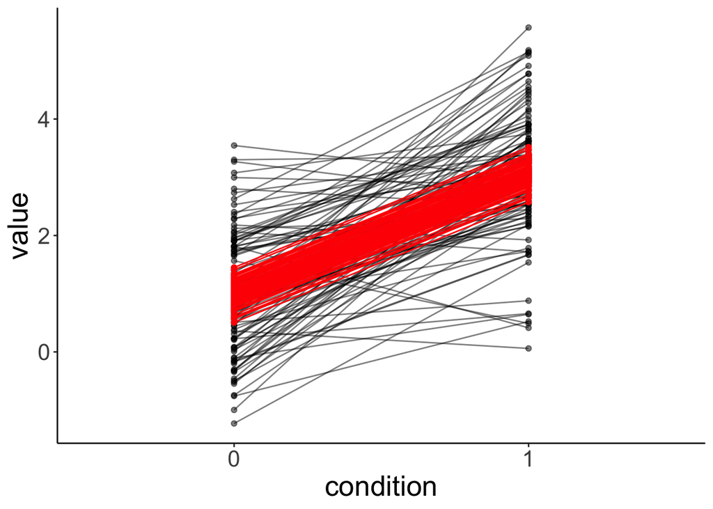

```r
fit.mixed %>%
  augment() %>%
  clean_names() %>%
  ggplot(data = .,
         mapping = aes(x = condition,
                       y = value,
                       group = participant)) +
  geom_point(alpha = 0.5) +
  geom_line(alpha = 0.5) +
  geom_point(aes(y = fitted),
             color = "red") +
  geom_line(aes(y = fitted),
             color = "red")
```

Let’s simulate some data from this fitted model:

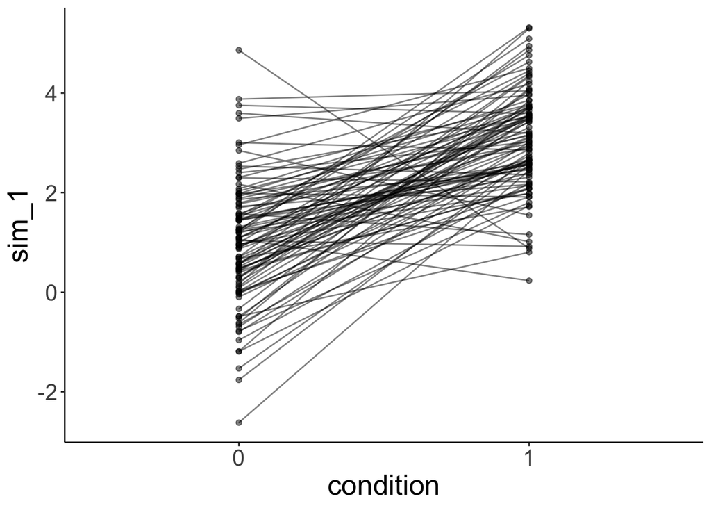

```r
# simulated data
fit.mixed %>%
  simulate() %>%
  bind_cols(df.mixed) %>%
  ggplot(data = .,
         mapping = aes(x = condition,
                       y = sim_1,
                       group = participant)) +
  geom_line(alpha = 0.5) +
  geom_point(alpha = 0.5)
```

Even though we only fitted random intercepts in this model, when we simulate from the model, we get different slopes since, when simulating new data, the model takes our uncertainty in the residuals into account as well.

Let’s see whether fitting random intercepts was worth it in this case:

```r
# using chisq test
fit.compact = lm(formula = value ~ 1 +  condition,
                data = df.mixed)

fit.augmented = lmer(formula = value ~ 1 + condition +  (1 | participant),
                data = df.mixed)

anova(fit.augmented, fit.compact)
```

```
#> refitting model(s) with ML (instead of REML)
```

```
#> Data: df.mixed
#> Models:
#> fit.compact: value ~ 1 + condition
#> fit.augmented: value ~ 1 + condition + (1 | participant)
#>               Df   AIC    BIC logLik deviance  Chisq Chi Df Pr(>Chisq)
#> fit.compact    3 608.6 618.49 -301.3    602.6
#> fit.augmented  4 608.8 621.99 -300.4    600.8 1.7999      1     0.1797
```

Nope, it’s not worth it in this case. That said, even though having random intercepts does not increase the likelihood of the data given the model significantly, we should still include random intercepts to capture the dependence in the data.

## 18.3 The effect of outliers

Let’s take 20 participants from our `df.mixed` data set, and make one of the participants be an outlier:

```r
# let's make one outlier
df.outlier = df.mixed %>%
  mutate(participant = participant %>% as.character() %>% as.numeric()) %>%
  filter(participant <= 20) %>%
  mutate(value = ifelse(participant == 20, value + 30, value),
         participant = as.factor(participant))
```

Let’s fit the model and look at the summary:

```r
# fit model
fit.outlier = lmer(formula = value ~ 1 + condition + (1 | participant),
                   data = df.outlier)

fit.outlier %>%
  summary()
```

```
#> Linear mixed model fit by REML ['lmerMod']
#> Formula: value ~ 1 + condition + (1 | participant)
#>    Data: df.outlier
#>
#> REML criterion at convergence: 192
#>
#> Scaled residuals:
#>      Min       1Q   Median       3Q      Max
#> -1.44598 -0.48367  0.03043  0.44689  1.41232
#>
#> Random effects:
#>  Groups      Name        Variance Std.Dev.
#>  participant (Intercept) 45.1359  6.7183
#>  Residual                 0.6738  0.8209
#> Number of obs: 40, groups:  participant, 20
#>
#> Fixed effects:
#>             Estimate Std. Error t value
#> (Intercept)   2.7091     1.5134   1.790
#> condition1    2.1512     0.2596   8.287
#>
#> Correlation of Fixed Effects:
#>            (Intr)
#> condition1 -0.086
```

The variance for the participants’ intercepts has increased dramatically!

Let’s visualize the data together with the model’s predictions:

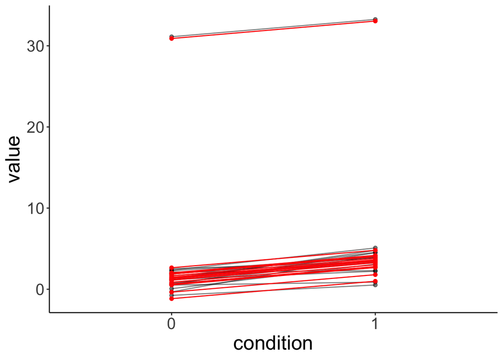

```r
fit.outlier %>%
  augment() %>%
  clean_names() %>%
  ggplot(data = .,
         mapping = aes(x = condition,
                       y = value,
                       group = participant)) +
  geom_point(alpha = 0.5) +
  geom_line(alpha = 0.5) +
  geom_point(aes(y = fitted),
             color = "red") +
  geom_line(aes(y = fitted),
             color = "red")
```

The model is still able to capture the participants quite well. But note what its simulated data looks like now:

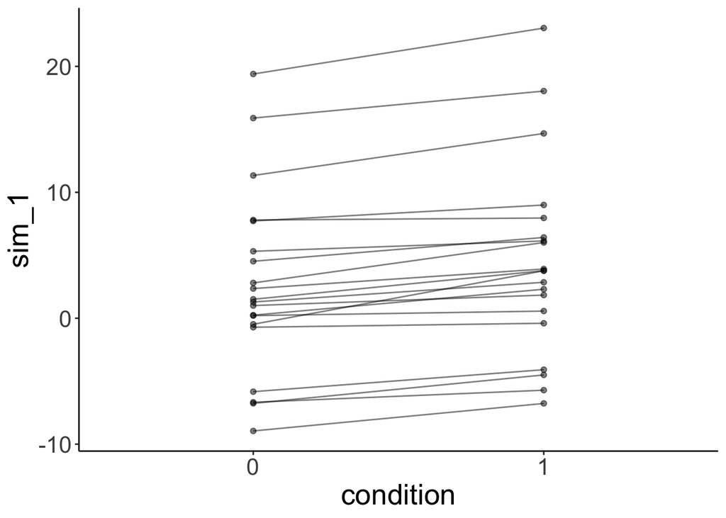

```r
# simulated data from lmer with outlier
fit.outlier %>%
  simulate() %>%
  bind_cols(df.outlier) %>%
  ggplot(data = .,
         mapping = aes(x = condition,
                       y = sim_1,
                       group = participant)) +
  geom_line(alpha = 0.5) +
  geom_point(alpha = 0.5)
```

The simulated data doesn’t look like our original data. This is because one normal distribution is used to model the variance in the intercepts between participants.

## 18.4 Different slopes

Let’s generate data where the effect of condition is different for participants:

```r
# make example reproducible
set.seed(1)

tmp = rnorm(n = 20)

df.slopes = tibble(
  condition = rep(1:2, each = 20),
  participant = rep(1:20, 2),
  value = ifelse(condition == 1, tmp,
                 mean(tmp) + rnorm(n = 20, sd = 0.3)) # regression to the mean
) %>%
  mutate(condition = as.factor(condition),
         participant = as.factor(participant))
```

Let’s fit a model with random intercepts.

```r
fit.slopes = lmer(formula = value ~ 1 + condition + (1 | participant),
                data = df.slopes)
```

```
#> boundary (singular) fit: see ?isSingular
```

```r
fit.slopes %>% summary()
```

```
#> Linear mixed model fit by REML ['lmerMod']
#> Formula: value ~ 1 + condition + (1 | participant)
#>    Data: df.slopes
#>
#> REML criterion at convergence: 83.6
#>
#> Scaled residuals:
#>     Min      1Q  Median      3Q     Max
#> -3.5808 -0.3184  0.0130  0.4551  2.0913
#>
#> Random effects:
#>  Groups      Name        Variance Std.Dev.
#>  participant (Intercept) 0.0000   0.0000
#>  Residual                0.4512   0.6717
#> Number of obs: 40, groups:  participant, 20
#>
#> Fixed effects:
#>              Estimate Std. Error t value
#> (Intercept)  0.190524   0.150197   1.268
#> condition2  -0.001941   0.212411  -0.009
#>
#> Correlation of Fixed Effects:
#>            (Intr)
#> condition2 -0.707
#> convergence code: 0
#> boundary (singular) fit: see ?isSingular
```

Note how the summary says “singular fit”, and how the variance for random intercepts is 0. Here, fitting random intercepts did not help the model fit at all, so the lmer gave up …

How about fitting random slopes?

```r
# fit model
lmer(formula = value ~ 1 + condition + (1 + condition | participant),
     data = df.slopes)
```

This won’t work because the model has more parameters than there are data points. To fit random slopes, we need more than 2 observations per participants.

## 18.5 Simpson’s paradox

Taking dependence in the data into account is extremely important. The Simpson’s paradox is an instructive example for what can go wrong when we ignore the dependence in the data.

Let’s start by simulating some data to demonstrate the paradox.

```r
# make example reproducible
set.seed(2)

n_participants = 20
n_observations = 10
slope = -10
sd_error = 0.4
sd_participant = 5
intercept = rnorm(n_participants, sd = sd_participant) %>% sort()

df.simpson = tibble(x = runif(n_participants * n_observations, min = 0, max = 1)) %>%
  arrange(x) %>%
  mutate(intercept = rep(intercept, each = n_observations),
         y = intercept + x * slope + rnorm(n(), sd = sd_error),
         participant = factor(intercept, labels = 1:n_participants))
```

Let’s visualize the overall relationship between `x` and `y` with a simple linear model.

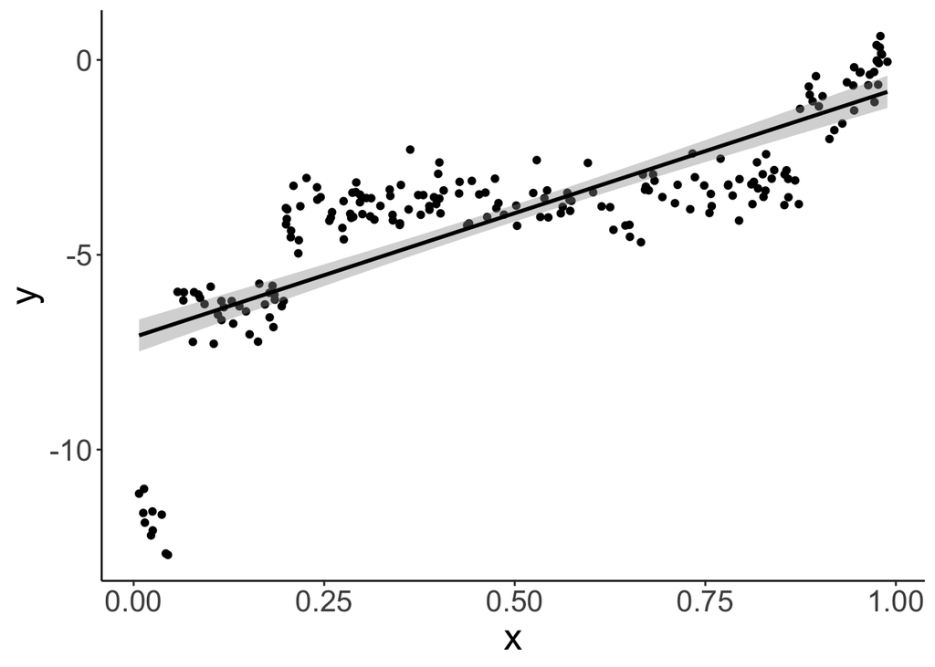

```r
# overall effect
ggplot(data = df.simpson,
       mapping = aes(x = x,
                     y = y)) +
  geom_point() +
  geom_smooth(method = "lm",
              color = "black")
```

As we see, overall, there is a positive relationship between `x` and `y`.

```r
lm(formula = y ~ x,
   data = df.simpson) %>%
  summary()
```

```
#>
#> Call:
#> lm(formula = y ~ x, data = df.simpson)
#>
#> Residuals:
#>     Min      1Q  Median      3Q     Max
#> -5.8731 -0.6362  0.2272  1.0051  2.6410
#>
#> Coefficients:
#>             Estimate Std. Error t value Pr(>|t|)
#> (Intercept)  -7.1151     0.2107  -33.76   <2e-16 ***
#> x             6.3671     0.3631   17.54   <2e-16 ***
#> ---
#> Signif. codes:  0 '***' 0.001 '**' 0.01 '*' 0.05 '.' 0.1 ' ' 1
#>
#> Residual standard error: 1.55 on 198 degrees of freedom
#> Multiple R-squared:  0.6083, Adjusted R-squared:  0.6064
#> F-statistic: 307.5 on 1 and 198 DF,  p-value: < 2.2e-16
```

And this relationship is significant.

Let’s take another look at the data use different colors for the different participants.

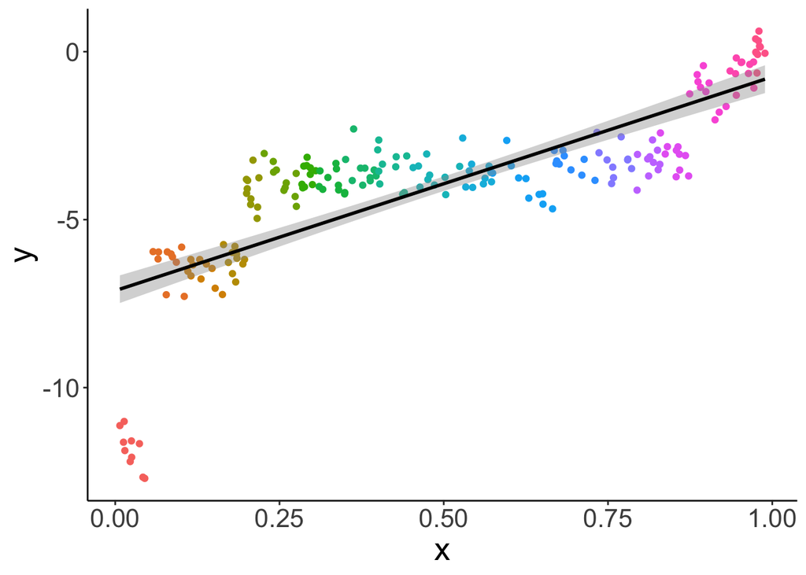

```r
# effect by participant
ggplot(data = df.simpson,
       mapping = aes(x = x,
                     y = y,
                     color = participant)) +
  geom_point() +
  geom_smooth(method = "lm",
              color = "black") +
  theme(legend.position = "none")
```

And let’s fit a different regression for each participant:

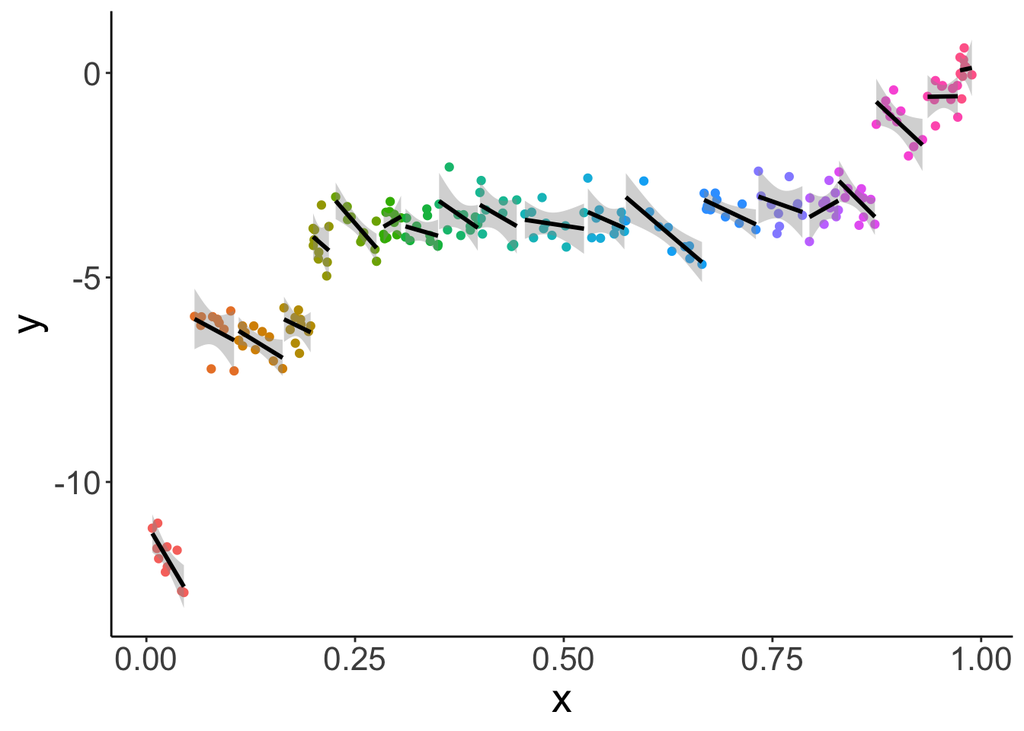

```r
# effect by participant
ggplot(data = df.simpson,
       mapping = aes(x = x,
                     y = y,
                     color = participant,
                     group = participant)) +
  geom_point() +
  geom_smooth(method = "lm",
              color = "black") +
  theme(legend.position = "none")
```

Let’s fit a linear mixed effects model with random intercepts:

```r
fit.lmer = lmer(formula = y ~ 1 + x + (1 | participant),
     data = df.simpson)

fit.lmer %>%
  summary()
```

```
#> Linear mixed model fit by REML ['lmerMod']
#> Formula: y ~ 1 + x + (1 | participant)
#>    Data: df.simpson
#>
#> REML criterion at convergence: 345.1
#>
#> Scaled residuals:
#>      Min       1Q   Median       3Q      Max
#> -2.43394 -0.59687  0.04493  0.62694  2.68828
#>
#> Random effects:
#>  Groups      Name        Variance Std.Dev.
#>  participant (Intercept) 21.4898  4.6357
#>  Residual                 0.1661  0.4075
#> Number of obs: 200, groups:  participant, 20
#>
#> Fixed effects:
#>             Estimate Std. Error t value
#> (Intercept)  -0.1577     1.3230  -0.119
#> x            -7.6678     1.6572  -4.627
#>
#> Correlation of Fixed Effects:
#>   (Intr)
#> x -0.621
```

As we can see, the fixed effect for `x` is now negative!

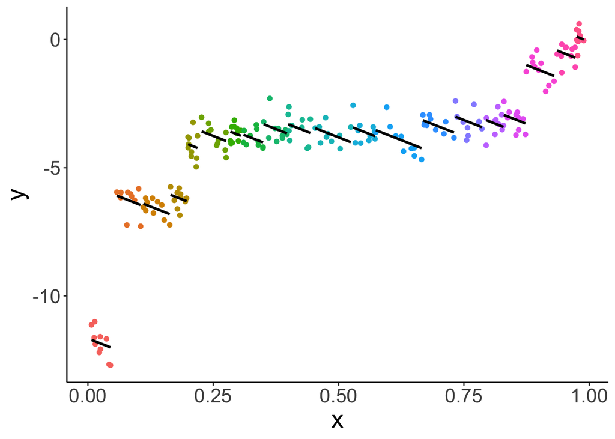

```r
fit.lmer %>%
  augment() %>%
  clean_names() %>%
  ggplot(data = .,
         aes(x = x,
             y = y,
             group = participant,
             color = participant)) +
  geom_point() +
  geom_line(aes(y = fitted),
            size = 1,
            color = "black") +
  theme(legend.position = "none")
```

Lesson learned: taking dependence into account is critical for drawing correct inferences!

## 18.6 Additional resources

### 18.6.1 Readings

- [Linear mixed effects models tutorial by Bodo Winter](https://arxiv.org/pdf/1308.5499.pdf)
- [Simpson’s paradox](https://paulvanderlaken.com/2017/09/27/simpsons-paradox-two-hr-examples-with-r-code/)
- [Tutorial on pooling](https://www.tjmahr.com/plotting-partial-pooling-in-mixed-effects-models/)

## References

Bates, Douglas, and Martin Maechler. 2019. *Matrix: Sparse and Dense Matrix Classes and Methods*. https://CRAN.R-project.org/package=Matrix.

Bates, Douglas, Martin Maechler, Ben Bolker, and Steven Walker. 2019. *Lme4: Linear Mixed-Effects Models Using ’Eigen’ and S4*. https://CRAN.R-project.org/package=lme4.

Bates, Douglas, Martin Mächler, Ben Bolker, and Steve Walker. 2015. “Fitting Linear Mixed-Effects Models Using lme4.” *Journal of Statistical Software* 67 (1): 1–48. https://doi.org/10.18637/jss.v067.i01.

Firke, Sam. 2019. *Janitor: Simple Tools for Examining and Cleaning Dirty Data*. https://CRAN.R-project.org/package=janitor.

Henry, Lionel, and Hadley Wickham. 2019. *Purrr: Functional Programming Tools*. https://CRAN.R-project.org/package=purrr.

Müller, Kirill, and Hadley Wickham. 2019. *Tibble: Simple Data Frames*. https://CRAN.R-project.org/package=tibble.

Pedersen, Thomas Lin. 2019. *Patchwork: The Composer of Plots*. https://CRAN.R-project.org/package=patchwork.

R Core Team. 2019. *R: A Language and Environment for Statistical Computing*. Vienna, Austria: R Foundation for Statistical Computing. https://www.R-project.org/.

Robinson, David, and Alex Hayes. 2019. *Broom: Convert Statistical Analysis Objects into Tidy Tibbles*. https://CRAN.R-project.org/package=broom.

Wickham, Hadley. 2016. *Ggplot2: Elegant Graphics for Data Analysis*. Springer-Verlag New York. https://ggplot2.tidyverse.org.

———. 2019a. *Forcats: Tools for Working with Categorical Variables (Factors)*. https://CRAN.R-project.org/package=forcats.

———. 2019b. *Stringr: Simple, Consistent Wrappers for Common String Operations*. https://CRAN.R-project.org/package=stringr.

———. 2019c. *Tidyverse: Easily Install and Load the ’Tidyverse’*. https://CRAN.R-project.org/package=tidyverse.

Wickham, Hadley, Mara Averick, Jennifer Bryan, Winston Chang, Lucy D’Agostino McGowan, Romain François, Garrett Grolemund, et al. 2019. “Welcome to the tidyverse.” *Journal of Open Source Software* 4 (43): 1686. https://doi.org/10.21105/joss.01686.

Wickham, Hadley, Winston Chang, Lionel Henry, Thomas Lin Pedersen, Kohske Takahashi, Claus Wilke, Kara Woo, and Hiroaki Yutani. 2019. *Ggplot2: Create Elegant Data Visualisations Using the Grammar of Graphics*. https://CRAN.R-project.org/package=ggplot2.

Wickham, Hadley, Romain François, Lionel Henry, and Kirill Müller. 2019. *Dplyr: A Grammar of Data Manipulation*. https://CRAN.R-project.org/package=dplyr.

Wickham, Hadley, and Lionel Henry. 2019. *Tidyr: Tidy Messy Data*. https://CRAN.R-project.org/package=tidyr.

Wickham, Hadley, Jim Hester, and Romain Francois. 2018. *Readr: Read Rectangular Text Data*. https://CRAN.R-project.org/package=readr.

Xie, Yihui. 2014. “Knitr: A Comprehensive Tool for Reproducible Research in R.” In *Implementing Reproducible Computational Research*, edited by Victoria Stodden, Friedrich Leisch, and Roger D. Peng. Chapman; Hall/CRC. http://www.crcpress.com/product/isbn/9781466561595.

———. 2015. *Dynamic Documents with R and Knitr*. 2nd ed. Boca Raton, Florida: Chapman; Hall/CRC. https://yihui.name/knitr/.

———. 2019. *Knitr: A General-Purpose Package for Dynamic Report Generation in R*. https://CRAN.R-project.org/package=knitr.

Zhu, Hao. 2019. *KableExtra: Construct Complex Table with ’Kable’ and Pipe Syntax*. https://CRAN.R-project.org/package=kableExtra.